# R-INLA implementation of the rational SPDE approach

David Bolin and Alexandre B. Simas

10/29/2021

## Introduction

In this vignette we will present the R-INLA implementation of the rational SPDE approach. For theoretical details we refer the reader to the Rational approximation with the `rSPDE` package vignette.

We begin by providing a step-by-step illustration on how to use our implementation. To this end we will consider a real world data set that consists of precipitation measurements from the Paraná region in Brazil.

After the initial model fitting, we will show how to change some parameters of the model.

In the end, we will also provide an example in which we have replicates.

It is important to mention that one can improve the performance by using the PARDISO solver. Please, go to (https://www.pardiso-project.org/r-inla/#license) to apply for a license. Also, use `inla.pardiso()` for instructions on how to enable the PARDISO sparse library.

## Example with real data

To illustrate our implementation of rSPDE in INLA we will consider a dataset available in INLA. This data has also been used to illustrate the SPDE approach, see for instance the book [Advanced Spatial Modeling with Stochastic Partial Differential Equations Using R and INLA](https://www.routledge.com/Advanced-Spatial-Modeling-with-Stochastic-Partial-Differential-Equations/Krainski-Gomez-Rubio-Bakka-Lenzi-Castro-Camilo-Simpson-Lindgren-Rue/p/book/9780367570644) and also the vignette [Spatial Statistics using R-INLA and Gaussian Markov random fields](https://sites.stat.washington.edu/peter/591/INLA.html).

The data consist of precipitation measurements from the Paraná region in Brazil and were provided by the Brazilian National Water Agency. The data were collected at 616 gauge stations in Paraná state, south of Brazil, for each day in 2011.

### A rSPDE model for precipitation

We will follow the vignette [Spatial Statistics using R-INLA and Gaussian Markov random fields](https://sites.stat.washington.edu/peter/591/INLA.html). As precipitation data are always positive, we will assume it is Gamma distributed. INLA uses the following parameterization of the Gamma distribution,
$$\Gamma(\mu, c\phi): \pi (y) = \frac{1}{\Gamma(c\phi)} \left(\frac{c\phi}{\mu}\right)^{c\phi} y^{c\phi - 1} \exp\left(-\frac{c\phi y}{\mu}\right) .$$
In this parameterization, the distribution has expected value $E(x) = \mu$ and variance $V(x) = \mu^2/(c\phi)$, where $c$ is a fixed (known) scaling parameter and $1/\phi$ is a dispersion parameter.

In this example $\mu$ will be modelled using a stochastic model that includes both covariates and spatial structure, resulting in the latent Gaussian model for the precipitation measurements
$$\begin{align} y_i\mid \mu(s_i), \theta &\sim \Gamma(\mu(s_i),c\phi)\\ \log (\mu(s)) &= \eta(s) = \sum_k f_k(c_k(s))+u(s)\\ \theta &\sim \pi(\theta) \end{align}.$$

where $y_i$ denotes the measurement taken at location $s_i$, $c_k(s)$ are covariates, $u(s)$ is a mean-zero Gaussian Matérn field, and $\theta$ is a vector containing all parameters of the model, including smoothness of the field. That is, by using the rSPDE model, we will also be able to estimate the smoothness of the latent field.

### Examining the data

We will be using INLA. To install INLA go to [R-INLA Project](https://www.r-inla.org/download-install).

We begin by loading some libraries we need to get the data and build the plots.

```r
library(gridExtra)
library(ggplot2)
library(lattice)
library(INLA)
library(splancs)
library(fields)
```

Let us load the data and the border of the region

```r
data(PRprec)
data(PRborder)
```

The data frame contains daily measurements at 616 stations for the year 2011, as well as coordinates and altitude information for the measurement stations. We will not analyze the full spatio-temporal data set, but instead look at the total precipitation in January, which we calculate as

```r
Y <- rowMeans(PRprec[, 3 + 1:31])
```

In the next snippet of code, we extract the coordinates and altitudes and remove the locations with missing values.

```r
ind <- !is.na(Y)
Y <- Y[ind]
coords <- as.matrix(PRprec[ind, 1:2])
alt <- PRprec$Altitude[ind]
```

Let us build a plot for the precipitations:

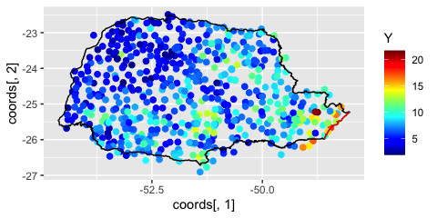

```r
ggplot() + geom_point(aes(x = coords[, 1], y = coords[, 2], colour = Y),
                      size = 2, alpha = 1) +
  scale_colour_gradientn(colours = tim.colors(100)) +
  geom_path(aes(x = PRborder[, 1], y = PRborder[, 2])) +
  geom_path(aes(x = PRborder[1034:1078, 1],
                y = PRborder[1034:1078, 2]), colour = "red")
```

The red line in the figure shows the coast line, and we expect the distance to the coast to be a good covariate for precipitation.

This covariate is not available, so let us calculate it for each observation location:

```r
seaDist <- apply(spDists(coords, PRborder[1034:1078, ],
                         longlat = TRUE), 1, min)
```

Now, let us plot the precipitation as a function of the possible covariates:

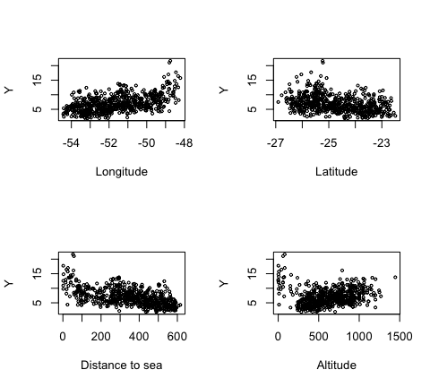

```r
par(mfrow = c(2, 2))
plot(coords[, 1], Y, cex = 0.5, xlab = "Longitude")
plot(coords[, 2], Y, cex = 0.5, xlab = "Latitude")
plot(seaDist, Y, cex = 0.5, xlab = "Distance to sea")
plot(alt, Y, cex = 0.5, xlab = "Altitude")
```

```r
par(mfrow = c(1, 1))
```

### Creating the rSPDE model

To use the INLA implementation of the rSPDE model we need to load the functions:

```r
library(rSPDE)
```

The rSPDE-INLA implementation is very reminiscent of INLA, so its usage should be straightforward for INLA users. For instance, to create a rSPDE model, one would `rpsde.matern()` in place of `inla.spde2.matern()`. To create an index, one should use `rspde.make.index()` in place of `inla.spde.make.index()`. To create the `A` matrix, one should use `rspde.make.A()` in place of `inla.spde.make.A()`, and so on.

The main differences when comparing the arguments between the rSPDE-INLA implementation and the standard SPDE implementation in INLA, are the `nu` and `rspde_order` arguments, which are present in rSPDE-INLA implementation. We will see below how use these arguments.

#### Mesh

We can use INLA for creating the mesh. Let us create a mesh which is based on a non-convex hull to avoid adding many small triangles outside the domain of interest (more triangles = larger computation times):

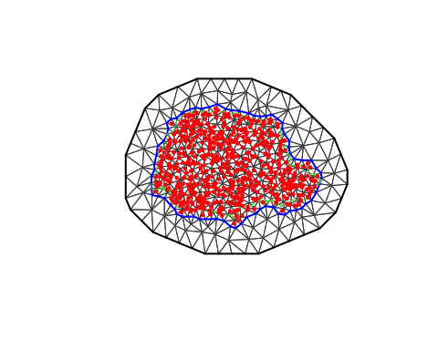

```r
prdomain <- inla.nonconvex.hull(coords, -0.03, -0.05, resolution = c(100, 100))
prmesh <- inla.mesh.2d(boundary = prdomain, max.edge = c(0.45, 1), cutoff = 0.2)
plot(prmesh, asp = 1, main = "")
lines(PRborder, col = 3)
points(coords[, 1], coords[, 2], pch = 19, cex = 0.5, col = "red")
```

#### The observation matrix (A)

We now create the $A$ matrix, that connects the mesh to the observation locations and then create the rSPDE model.

For this task, as we mentioned earlier, we need to use a rSPDE specific function, whose name is very reminiscent to INLA’s standard SPDE approach, namely `rspde.make.A()` (in place of INLA’s `inla.spde.make.A()`). The reason for the need of this specific function is that the size of the $A$ matrix depends on the order of the rational approximation. The details can be found in the introduction of this vignette.

The default order is 2 for our covariance-based rational approximation. As mentioned in the introduction, an approximation of order 2 in the covariance-based rational approximation has approximately the same computational cost as the standard rational approximation of order 1.

Recall that the latent process $u$ is a solution of
$$(\kappa^2 I-\Delta)^{\alpha/2}(\tau u) = \mathcal{W},$$
where $\alpha = \nu + d/2$.

We want to estimate $\tau,\kappa$ and $\nu$.

There is also an option to fix the smoothness parameter $\nu$ to some predefined value and only estimate $\tau$ and $\kappa$.

By default the rSPDE-INLA implementation estimates all the three parameters.

In this first example we will assume we want a rational approximation of order 2, where we also want to estimate the smoothness parameter $\nu$.

To this end we can use the `rspde.make.A()` function. Since we will assume order 2 and that we want to estimate smoothness, which are the default options in this function, the required parameters are simply the mesh and the locations:

```r
Abar <- rspde.make.A(mesh = prmesh, loc = coords)
```

#### Setting up the rSPDE model

To set up a rSPDE model, all we need is the mesh. By default it will assume that we want to estimate the smoothness parameter $\nu$ and to do a covariance-based rational approximation of order 2.

Later in this vignette we will also see other options for setting up rSPDE models such as keeping the smoothness parameter fixed and/or increasing the order of the covariance-based rational approximation.

Therefore, to set up a model all we have to do is use the `rspde.matern()` function:

```r
rspde_model <- rspde.matern(mesh = prmesh)
```

Notice that this function is very reminiscent of INLA’s `inla.spde2.matern()` function.

This is a pattern we tried to keep consistent. All the rSPDE versions of some INLA function will either replace `inla` or `inla.spde` or `inla.spde2` by `rspde`.

#### The `inla.stack`

Since the covariates already are evaluated at the observation locations, we only want to apply the $A$ matrix to the spatial effect and not the fixed effects. We can use the `inla.stack()` function.

The difference, however, is that we need to use the function `rspde.make.index()` (in place of the standard `inla.spde.make.index()`) to create the index.

If one is using the default options, that is, to estimate the smoothness parameter $\nu$ and to do a rational approximation of order 2, the usage of `rspde.make.index()` is identical to the usage of `inla.spde.make.index()`:

```r
mesh.index <- rspde.make.index(name = "field", mesh = prmesh)
```

We can then create the stack in a standard manner:

```r
stk.dat <- inla.stack(
  data = list(y = Y), A = list(Abar, 1), tag = "est",
  effects = list(c(mesh.index,
                   list(Intercept = 1)),
                 list(long = inla.group(coords[, 1]),
                      lat = inla.group(coords[,2]),
                      seaDist = inla.group(seaDist))))
```

Here the observation matrix $A$ is applied to the spatial effect and the intercept while an identity observation matrix, denoted by $1$, is applied to the covariates. This means the covariates are unaffected by the observation matrix.

The observation matrices in $A=list(Abar,1)$ are used to link the corresponding elements in the effects-list to the observations. Thus in our model the latent spatial field `mesh.index` and the intercept are linked to the log-expectation of the observations, i.e. $\eta(s)$, through the $A$-matrix. The covariates, on the other hand, are linked directly to $\eta(s)$. The `stk.dat` object defined above implies the following principal linkage between model components and observations
$$\eta(s) \sim A x(s) + A \text{ Intercept} + \text{long} + \text{lat}+ \text{seaDist}.$$
$\eta(s)$ will then be used in the observation-likelihood,
$$y_i\mid \eta(s_i),\theta \sim \Gamma(\exp(\eta (s_i)), c\phi).$$

### Model fitting

We will build a model using the distance to the sea $x_i$ as a covariate through an improper CAR(1) model with $\beta_{ij}=1(i\sim j)$, which INLA calls a random walk of order 1.

```r
f.s <- y ~ -1 + Intercept +  f(seaDist, model = "rw1") +
  f(field, model = rspde_model)
```

Here `-1` is added to remove R’s implicit intercept, which is replaced by the explicit `+Intercept` from when we created the stack.

To fit the model we proceed as in the standard SPDE approach and we simply call INLA. It is noteworthy that we can have a performance enhancement by using the argument `inla.mode = "experimental"`. As argued in `INLA`’s man page, not all features are available in `inla.mode="experimental"`, and we will need to use the `"classic"` mode (the default mode) instead of `"experimental"` whenever we are doing predictions.

```r
rspde_fit <- inla(f.s, family = "Gamma", data = inla.stack.data(stk.dat),
            verbose = FALSE,
            control.inla=list(int.strategy='eb'),
            control.predictor = list(A = inla.stack.A(stk.dat), compute = TRUE),
            inla.mode = "experimental")
```

### INLA results

We can look at some summaries of the posterior distributions for the parameters, for example the fixed effects (i.e. the intercept) and the hyper-parameters (i.e. dispersion in the gamma likelihood, the precision of the RW1, and the parameters of the spatial field):

```r
summary(rspde_fit)
```

```
##
## Call:
##    c("inla(formula = f.s, family = \"Gamma\", data =
##    inla.stack.data(stk.dat), ", " verbose = FALSE, control.predictor =
##    list(A = inla.stack.A(stk.dat), ", " compute = TRUE), control.inla =
##    list(int.strategy = \"eb\"), ", " inla.mode = \"experimental\")")
## Time used:
##     Pre = 4.23, Running = 18.3, Post = 0.144, Total = 22.6
## Fixed effects:
##            mean    sd 0.025quant 0.5quant 0.975quant  mode kld
## Intercept 0.648 0.019      0.611    0.648      0.685 0.648   0
##
## Random effects:
##   Name     Model
##     seaDist RW1 model
##    field RGeneric2
##
## Model hyperparameters:
##                                                     mean       sd 0.025quant
## Precision parameter for the Gamma observations    13.122    0.878     11.432
## Precision for seaDist                          11651.775 9540.717   3446.182
## Theta1 for field                                  -1.112    0.441     -1.933
## Theta2 for field                                   0.947    0.331      0.219
## Theta3 for field                                  -0.740    0.444     -1.535
##                                                0.5quant 0.975quant     mode
## Precision parameter for the Gamma observations   13.112     14.889   13.119
## Precision for seaDist                          8788.831  36896.355 5750.033
## Theta1 for field                                 -1.132     -0.197   -1.203
## Theta2 for field                                  0.981      1.503    1.107
## Theta3 for field                                 -0.769      0.199   -0.878
##
## Marginal log-Likelihood:  -1262.23
## Posterior summaries for the linear predictor and the fitted values are computed
## (Posterior marginals needs also 'control.compute=list(return.marginals.predictor=TRUE)')
```

Let $\theta_1 = Theta1$, $\theta_2=Theta2$ and $\theta_3=Theta3$. In terms of the SPDE
$$(\kappa^2 I - \Delta)^{\alpha/2}(\tau u) = \mathcal{W},$$
where $\alpha = \nu + d/2$, we have that
$$\tau = \exp(\theta_1),\quad \kappa = \exp(\theta_2),$$
and by default
$$\nu = 4\Big(\frac{\exp(\theta_3)}{1+\exp(\theta_3)}\Big).$$
The number 4 comes from the upper bound for $\nu$, which will be discussed later in this vignette and the logit link function comes from the default choice of the prior distribution for $\nu$, which is beta.

In general, for beta prior distribution for the smoothness parameter (the default) the link function is
$$\nu = \nu_{UB}\Big(\frac{\exp(\theta_3)}{1+\exp(\theta_3)}\Big),$$
where $\nu_{UB}$ is the value of the upper bound for the smoothness parameter $\nu$.

Another choice for prior for $\nu$ is a truncated lognormal distribution and will also be discussed later in this vignette.

### rSPDE-INLA results

We can obtain outputs with respect to parameters in the original scale by using the function `rspde.result()`:

```r
result_fit <- rspde.result(rspde_fit, "field", rspde_model)
summary(result_fit)
```

```
##           mean       sd 0.025quant 0.5quant 0.975quant     mode
## tau   0.362726 0.174063   0.145954 0.322524   0.820497 0.258883
## kappa 2.711410 0.840998   1.255290 2.669960   4.493530 2.551030
## nu    1.317470 0.383397   0.711907 1.266650   2.200550 1.126460
```

We can also plot the posterior densities:

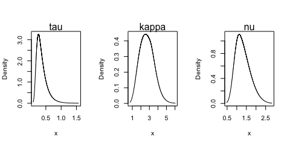

```r
par(mfrow=c(1,3))
plot(result_fit, caption=c("tau","kappa","nu"))
```

This function is reminiscent to the `inla.spde.result()` function with the main difference that it has the `summary` and `plot` methods implemented.

### Predictions

Let us now obtain predictions (i.e. do kriging) of the expected precipitation on a dense grid in the region.

We begin by creating the grid in which we want to do the predictions. To this end, we can use the `rspde.mesh.projector()` function. This function has the same arguments as the function `inla.mesh.projector()` the only difference being that the rSPDE version also has an argument `nu` and an argument `rspde_order`. Thus, we proceed in the same fashion as we would in INLA’s standard SPDE implementation:

```r
nxy <- c(150, 100)
projgrid <- rspde.mesh.projector(prmesh, xlim = range(PRborder[, 1]),
ylim = range(PRborder[,2]), dims = nxy)
```

This lattice contains 150 × 100 locations. One can easily change the resolution of the kriging prediction by changing `nxy`. Let us find the cells that are outside the region of interest so that we do not plot the estimates there.

```r
xy.in <- inout(projgrid$lattice$loc, cbind(PRborder[, 1], PRborder[, 2]))
```

Let us plot the locations that we will do prediction:

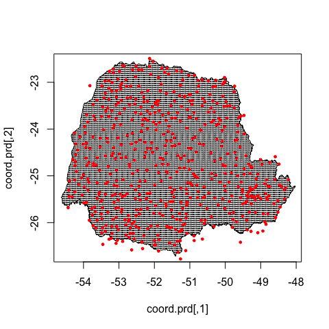

```r
coord.prd <- projgrid$lattice$loc[xy.in, ]
plot(coord.prd, type = "p", cex = 0.1)
lines(PRborder)
points(coords[, 1], coords[, 2], pch = 19, cex = 0.5, col = "red")
```

Now, there are a few ways we could calculate the kriging prediction. The simplest way is to evaluate the mean of all individual random effects in the linear predictor and then to calculate the exponential of their sum (since $\mu(s)=\exp(\eta(s))$ ). A more accurate way is to calculate the prediction jointly with the estimation, which unfortunately is quite computationally expensive if we do prediction on a fine grid. However, in this illustration, we proceed with this option to show how one can do it.

To this end, first, link the prediction coordinates to the mesh nodes through an $A$ matrix

```r
A.prd <- projgrid$proj$A[xy.in, ]
```

Since we are using distance to the sea as a covariate, we also have to calculate this covariate for the prediction locations.

```r
seaDist.prd <- apply(spDists(coord.prd,
    PRborder[1034:1078, ], longlat = TRUE), 1, min)
```

We now make a stack for the prediction locations. We have no data at the prediction locations, so we set `y= NA`. We then join this stack with the estimation stack.

```r
ef.prd = list(c(mesh.index, list(Intercept = 1)),
    list(long = inla.group(coord.prd[,
    1]), lat = inla.group(coord.prd[, 2]),
    seaDist = inla.group(seaDist.prd)))
stk.prd <- inla.stack(data = list(y = NA),
    A = list(A.prd, 1), tag = "prd",
    effects = ef.prd)
stk.all <- inla.stack(stk.dat, stk.prd)
```

Doing the joint estimation takes a while, and we therefore turn off the computation of certain things that we are not interested in, such as the marginals for the random effect. We will also use a simplified integration strategy (actually only using the posterior mode of the hyper-parameters) through the command `control.inla = list(int.strategy = "eb")`, i.e. empirical Bayes. Since we are doing predictions, we should not use `INLA`’s experimental mode.

```r
rspde_fitprd <- inla(f.s, family = "Gamma",
             data = inla.stack.data(stk.all),
             control.predictor = list(A = inla.stack.A(stk.all),
                                      compute = TRUE, link = 1),
             control.compute = list(return.marginals = FALSE,
                                    return.marginals.predictor = FALSE),
             control.inla = list(int.strategy = "eb"))
```

We then extract the indices to the prediction nodes and then extract the mean and the standard deviation of the response:

```r
id.prd <- inla.stack.index(stk.all, "prd")$data
sd.prd <- m.prd <- matrix(NA, nxy[1], nxy[2])
m.prd[xy.in] <- rspde_fitprd$summary.fitted.values$mean[id.prd]
sd.prd[xy.in] <- rspde_fitprd$summary.fitted.values$sd[id.prd]
```

Finally, we plot the results:

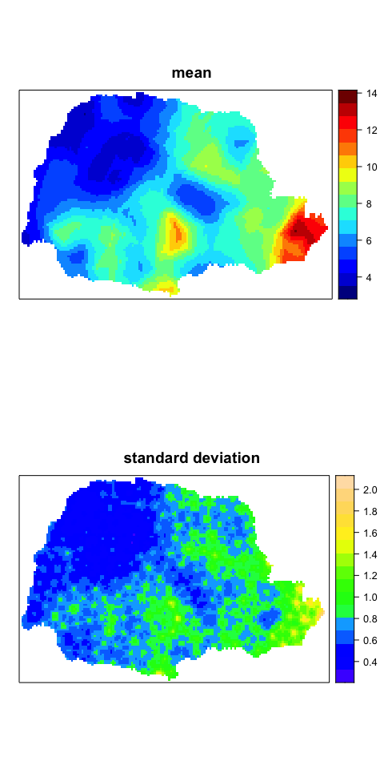

```r
#Plot the predictions
grid.arrange(levelplot(m.prd, col.regions = tim.colors(99),
             xlab = "", ylab = "", main = "mean",
                       scales = list(draw = FALSE)),
             levelplot(sd.prd, col.regions = topo.colors(99),
             xlab = "", ylab = "", scales = list(draw = FALSE),
                       main = "standard deviation"))
```

## Further options of the rSPDE-INLA implementation

We will now discuss some of the arguments that were introduced in our R-INLA implementation of the rational approximation that are not present in INLA’s standard SPDE implementation.

In each case we will provide an illustrative example.

### Changing the upper bound for the smoothness parameter

When we fit a `rspde.matern()` model we need to provide an upper bound for the smoothness parameter $\nu$. The reason for that is that the sparsity of the precision matrix should be kept fixed during INLA’s estimation and the higher the value of $\nu$ the denser the precision matrix gets.

This means that the higher the value of $\nu$, the higher the computational cost to fit the model. Therefore, ideally, want to choose an upper bound for $\nu$ as small as possible.

To change the value of the upper bound for the smoothness parameter, we must change the argument `nu_upper_bound`. The default value for `nu_upper_bound` is 4. Other common choices for `nu_upper_bound` are 2 and 1.

However, if we choose a value of `nu_upper_bound` which is too low, the “correct” value of $\nu$ might not belong to the interval $(0,\nu_{UB})$, where $\nu_{UB}$ is the value of `nu_upper_bound`. Hence, one might be forced to increase `nu_upper_bound` and estimate again, which, obviously will increase the computational cost as we will need to do more than one estimation.

Let us illustrate by considering the same model we considered above for the precipitation in Paraná region in Brazil and consider `nu_upper_bound` equal to 2, which is generally a good choice for `nu_upper_bound`.

We simply use the function `rspde.matern()` with the argument `nu_upper_bound` set to 2:

```r
rspde_model_2 <- rspde.matern(mesh = prmesh, nu_upper_bound = 2)
```

Since we are considering the default `rspde_order`, the $A$ matrix and the mesh index objects are the same as the previous ones. Let us then update the formula and fit the model:

```r
f.s.2 <- y ~ -1 + Intercept +  f(seaDist, model = "rw1") +
  f(field, model = rspde_model_2)

rspde_fit_2 <- inla(f.s.2, family = "Gamma", data = inla.stack.data(stk.dat),
            verbose = FALSE,
            control.inla=list(int.strategy='eb'),
            control.predictor = list(A = inla.stack.A(stk.dat), compute = TRUE),
            inla.mode = "experimental")
```

Let us see the summary of the fit:

```r
summary(rspde_fit_2)
```

```
##
## Call:
##    c("inla(formula = f.s.2, family = \"Gamma\", data =
##    inla.stack.data(stk.dat), ", " verbose = FALSE, control.predictor =
##    list(A = inla.stack.A(stk.dat), ", " compute = TRUE), control.inla =
##    list(int.strategy = \"eb\"), ", " inla.mode = \"experimental\")")
## Time used:
##     Pre = 5.65, Running = 21.1, Post = 0.0843, Total = 26.8
## Fixed effects:
##            mean    sd 0.025quant 0.5quant 0.975quant  mode kld
## Intercept 0.648 0.019       0.61    0.648      0.685 0.648   0
##
## Random effects:
##   Name     Model
##     seaDist RW1 model
##    field RGeneric2
##
## Model hyperparameters:
##                                                    mean       sd 0.025quant
## Precision parameter for the Gamma observations   13.214    0.753     11.832
## Precision for seaDist                          7911.801 3769.914   2793.738
## Theta1 for field                                 -1.393    0.280     -1.931
## Theta2 for field                                  1.184    0.200      0.801
## Theta3 for field                                  0.523    0.470     -0.452
##                                                0.5quant 0.975quant    mode
## Precision parameter for the Gamma observations   13.179     14.798   13.09
## Precision for seaDist                          7195.128  17349.182 5870.37
## Theta1 for field                                 -1.401     -0.816   -1.43
## Theta2 for field                                  1.179      1.591    1.16
## Theta3 for field                                  0.538      1.418    0.59
##
## Marginal log-Likelihood:  -1261.24
## Posterior summaries for the linear predictor and the fitted values are computed
## (Posterior marginals needs also 'control.compute=list(return.marginals.predictor=TRUE)')
```

Let us compare with the cost from the previous fit, with the default value of `nu_upper_bound` of 4:

```r
# nu_upper_bound = 4
rspde_fit$cpu.used
```

```
##        Pre    Running       Post      Total
##  4.2251961 18.2761331  0.1443379 22.6456671
```

```r
#nu_upper_bound = 2
rspde_fit_2$cpu.used
```

```
##         Pre     Running        Post       Total
##  5.64590693 21.05339789  0.08428597 26.78359079
```

Finally, let us get the result the user’s scale and see the estimate for $\nu$:

```r
result_fit_2 <- rspde.result(rspde_fit_2, "field", rspde_model_2)
summary(result_fit_2)
```

```
##           mean        sd 0.025quant 0.5quant 0.975quant     mode
## tau   0.258098 0.0747294   0.146900 0.246263   0.440416 0.223365
## kappa 3.331630 0.6783640   2.238380 3.252760   4.909710 3.082780
## nu    1.243120 0.2117080   0.788879 1.263370   1.608070 1.314500
```

### Changing the order of the rational approximation

To change the order of the rational approximation all we have to do is set the argument `rspde_order` to the desired value. The current available possibilities are `1,2,3`,…, up to `8`.

The higher the order of the rational approximation, the more accurate the results will be, however, the higher the computational cost will be.

The default `rspde_order` of 2 is, generally, a good choice and reasonably accurate. See the vignette Covariance-based rational approximation with the `rSPDE` package for further details on the order of the rational approximation and some comparison with the Matérn covariance.

Let us fit the above model with the covariance-based rational approximation of order `3`. Notice that since we are changing the order of the rational approximation, that is, we are changing the `rspde_order` argument, we need to recompute the $A$ matrix and the mesh index. Therefore, we proceed as follows:

- We build a new model:

```r
rspde_model_order_3 <- rspde.matern(mesh = prmesh, rspde_order = 3,
                              nu_upper_bound = 2)
```

- We create a new $A$ matrix:

```r
Abar_3 <- rspde.make.A(mesh = prmesh, loc = coords, rspde_order = 3)
```

- We create a new index:

```r
mesh.index.3 <- rspde.make.index(name = "field", mesh = prmesh,
                                 rspde_order = 3)
```

Now the remaining is standard:

```r
stk.dat.3 <- inla.stack(
  data = list(y = Y), A = list(Abar_3, 1), tag = "est",
  effects = list(c(mesh.index.3,
                   list(Intercept = 1)),
                 list(long = inla.group(coords[, 1]),
                      lat = inla.group(coords[,2]),
                      seaDist = inla.group(seaDist))))

f.s.3 <- y ~ -1 + Intercept +  f(seaDist, model = "rw1") +
  f(field, model = rspde_model_order_3)

rspde_fit_order_3 <- inla(f.s.3, family = "Gamma", data = inla.stack.data(stk.dat.3),
                    verbose = FALSE,
            control.inla=list(int.strategy='eb'),
            control.predictor = list(A = inla.stack.A(stk.dat.3), compute = TRUE),
            inla.mode = "experimental")
```

Let us see the summary:

```r
summary(rspde_fit_order_3)
```

```
##
## Call:
##    c("inla(formula = f.s.3, family = \"Gamma\", data =
##    inla.stack.data(stk.dat.3), ", " verbose = FALSE, control.predictor =
##    list(A = inla.stack.A(stk.dat.3), ", " compute = TRUE), control.inla =
##    list(int.strategy = \"eb\"), ", " inla.mode = \"experimental\")")
## Time used:
##     Pre = 5.77, Running = 23.4, Post = 0.0975, Total = 29.2
## Fixed effects:
##            mean    sd 0.025quant 0.5quant 0.975quant  mode kld
## Intercept 0.486 0.014      0.458    0.486      0.514 0.486   0
##
## Random effects:
##   Name     Model
##     seaDist RW1 model
##    field RGeneric2
##
## Model hyperparameters:
##                                                    mean       sd 0.025quant
## Precision parameter for the Gamma observations   13.175 2.12e-01     12.760
## Precision for seaDist                          6193.884 2.08e+05   2946.965
## Theta1 for field                                 -1.615 4.43e-01     -2.763
## Theta2 for field                                  1.221 1.75e-01      0.875
## Theta3 for field                                  0.739 3.78e-01      0.003
##                                                0.5quant 0.975quant     mode
## Precision parameter for the Gamma observations   13.159      13.67   13.111
## Precision for seaDist                          5959.363   11697.60 5980.271
## Theta1 for field                                 -1.618      -0.52   -1.509
## Theta2 for field                                  1.200       1.67    1.187
## Theta3 for field                                  0.692       1.70    0.666
##
## Marginal log-Likelihood:  -1259.93
## Posterior summaries for the linear predictor and the fitted values are computed
## (Posterior marginals needs also 'control.compute=list(return.marginals.predictor=TRUE)')
```

We can see in the above summary that the computational cost significantly increased. We can see that for this dataset, the cost of having `rspde_order=3` and `nu_upper_bound=2` is greater than `rspde_order=2` and `nu_upper_bound=4`:

```r
# nu_upper_bound = 4
rspde_fit$cpu.used
```

```
##        Pre    Running       Post      Total
##  4.2251961 18.2761331  0.1443379 22.6456671
```

```r
#nu_upper_bound = 2
rspde_fit_order_3$cpu.used
```

```
##         Pre     Running        Post       Total
##  5.77441907 23.35088897  0.09748507 29.22279310
```

Let us now see the summary in the original scale:

```r
result_fit_order_3 <- rspde.result(rspde_fit_order_3, "field", rspde_model_order_3)
summary(result_fit_order_3)
```

```
##           mean       sd 0.025quant 0.5quant 0.975quant     mode
## tau   0.223109 0.094561  0.0780865 0.206416   0.414111 0.176635
## kappa 3.408940 0.618948  2.5082700 3.369330   5.249650 3.138110
## nu    1.327830 0.156961  1.0447800 1.347870   1.687590 1.326440
```

Let us see the plots of the posterior marginal densities:

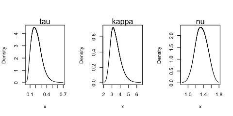

```r
par(mfrow=c(1,3))
plot(result_fit_order_3, caption=c("tau","kappa","nu"))
```

### Estimating models with fixed smoothness

We can fix the smoothness, say $\nu$, of the model by providing a non-NULL positive value for `nu`.

When the smoothness, $\nu$, is fixed, we can have two possibilities:

- $\alpha = \nu + d/2$ is integer;
- $\alpha = \nu + d/2$ is not integer.

The first case, i.e., when $\alpha$ is integer, has much less computational cost. Furthermore, the $A$ matrix is different than the $A$ matrix for the non-integer $\alpha$.

The $A$ matrix is the same for all values of $\nu$ such that $\alpha$ is integer. So, the $A$ matrix for these cases only need to be computed once. The same holds for the `index` obtained from the `rspde.make.index` function.

In the second case the $A$ matrix only depends on the order of the rational approximation and not on $\nu$. Therefore, if the matrix $A$ has already been computed for some `rspde_order`, then the $A$ matrix will be same for all the values of $\nu$ such that $\alpha$ is non-integer for that `rspde_order`. The same holds for the `index` obtained from the `rspde.make.index` function.

#### Estimating models with fixed smoothness and non-integer $\alpha$

Therefore, all we have to do is build a new model in which we set `nu` to `1.16`:

```r
rspde_model_fix <- rspde.matern(mesh = prmesh, rspde_order = 2,
                                       nu = 1.16)
```

Let us now fit the model:

```r
f.s.fix <- y ~ -1 + Intercept +  f(seaDist, model = "rw1") +
  f(field, model = rspde_model_fix)

rspde_fix <- inla(f.s.fix, family = "Gamma", data = inla.stack.data(stk.dat),
                verbose = FALSE,
              control.inla=list(int.strategy='eb'),
              control.predictor = list(A = inla.stack.A(stk.dat), compute = TRUE),
            inla.mode = "experimental")
```

Here we have the summary:

```r
summary(rspde_fix)
```

```
##
## Call:
##    c("inla(formula = f.s.fix, family = \"Gamma\", data =
##    inla.stack.data(stk.dat), ", " verbose = FALSE, control.predictor =
##    list(A = inla.stack.A(stk.dat), ", " compute = TRUE), control.inla =
##    list(int.strategy = \"eb\"), ", " inla.mode = \"experimental\")")
## Time used:
##     Pre = 5.58, Running = 19.2, Post = 0.0935, Total = 24.9
## Fixed effects:
##            mean    sd 0.025quant 0.5quant 0.975quant  mode kld
## Intercept 0.648 0.018      0.612    0.648      0.684 0.648   0
##
## Random effects:
##   Name     Model
##     seaDist RW1 model
##    field RGeneric2
##
## Model hyperparameters:
##                                                   mean       sd 0.025quant
## Precision parameter for the Gamma observations   13.22    0.877     11.572
## Precision for seaDist                          8430.79 5462.437   2553.469
## Theta1 for field                                 -1.20    0.283     -1.734
## Theta2 for field                                  1.12    0.281      0.549
##                                                0.5quant 0.975quant    mode
## Precision parameter for the Gamma observations    13.20     15.020   13.16
## Precision for seaDist                           6975.62  22778.626 5030.25
## Theta1 for field                                  -1.20     -0.619   -1.23
## Theta2 for field                                   1.13      1.654    1.16
##
## Marginal log-Likelihood:  -1261.86
## Posterior summaries for the linear predictor and the fitted values are computed
## (Posterior marginals needs also 'control.compute=list(return.marginals.predictor=TRUE)')
```

Now, the summary in the original scale:

```r
result_fix <- rspde.result(rspde_fix, "field", rspde_model_fix)
summary(result_fix)
```

```
##           mean        sd 0.025quant 0.5quant 0.975quant     mode
## tau   0.314641 0.0917803   0.177851 0.300192   0.538151 0.272327
## kappa 3.187130 0.8903230   1.739330 3.096500   5.232080 2.908650
```

#### Estimating models with fixed smoothness and integer $\alpha$

Since we are in dimension $d=2$, and $\nu>0$, the smallest value of $\nu$ that makes $\alpha = \nu + 1$ an integer is $\nu=1$. This value is also close to the estimated mean of the first model we fitted and enclosed by the posterior marginal density of $\nu$ for the first fit. Therefore, let us fit the model with $\nu=1$.

To this end we need to compute a new $A$ matrix:

```r
Abar.int <- rspde.make.A(mesh = prmesh, loc = coords,
                       nu = 1)
```

a new index:

```r
mesh.index.int <- rspde.make.index(name = "field", mesh = prmesh,
                                  nu = 1)
```

create a new model (remember to set `nu=1`):

```r
rspde_model_fix_int1 <- rspde.matern(mesh = prmesh,
                                     nu = 1)
```

The remaining is standard:

```r
stk.dat.int <- inla.stack(
  data = list(y = Y), A = list(Abar.int, 1), tag = "est",
  effects = list(c(mesh.index.int,
                   list(Intercept = 1)),
                 list(long = inla.group(coords[, 1]),
                      lat = inla.group(coords[,2]),
                      seaDist = inla.group(seaDist))))

f.s.fix.int.1 <- y ~ -1 + Intercept +  f(seaDist, model = "rw1") +
  f(field, model = rspde_model_fix_int1)

rspde_fix_int_1 <- inla(f.s.fix.int.1, family = "Gamma",
                      data = inla.stack.data(stk.dat.int), verbose = FALSE,
                  control.inla=list(int.strategy='eb'),
                  control.predictor = list(A = inla.stack.A(stk.dat.int),
                                           compute = TRUE),
            inla.mode = "experimental")
```

Let us check the summary:

```r
summary(rspde_fix_int_1)
```

```
##
## Call:
##    c("inla(formula = f.s.fix.int.1, family = \"Gamma\", data =
##    inla.stack.data(stk.dat.int), ", " verbose = FALSE, control.predictor =
##    list(A = inla.stack.A(stk.dat.int), ", " compute = TRUE), control.inla
##    = list(int.strategy = \"eb\"), ", " inla.mode = \"experimental\")")
## Time used:
##     Pre = 5.63, Running = 5.66, Post = 0.0651, Total = 11.4
## Fixed effects:
##            mean    sd 0.025quant 0.5quant 0.975quant  mode kld
## Intercept 1.945 0.053      1.841    1.945      2.048 1.945   0
##
## Random effects:
##   Name     Model
##     seaDist RW1 model
##    field RGeneric2
##
## Model hyperparameters:
##                                                    mean       sd 0.025quant
## Precision parameter for the Gamma observations   13.292    0.887     11.623
## Precision for seaDist                          7959.499 4833.409   2619.731
## Theta1 for field                                 -0.912    0.266     -1.419
## Theta2 for field                                  1.084    0.305      0.462
##                                                0.5quant 0.975quant     mode
## Precision parameter for the Gamma observations   13.267      15.11   13.222
## Precision for seaDist                          6694.763   20594.75 4964.487
## Theta1 for field                                 -0.919      -0.37   -0.945
## Theta2 for field                                  1.093       1.66    1.125
##
## Marginal log-Likelihood:  -1261.26
## Posterior summaries for the linear predictor and the fitted values are computed
## (Posterior marginals needs also 'control.compute=list(return.marginals.predictor=TRUE)')
```

and check the summary in the user’s scale:

```r
rspde_result_int <- rspde.result(rspde_fix_int_1, "field", rspde_model_fix_int1)
summary(rspde_result_int)
```

```
##           mean       sd 0.025quant 0.5quant 0.975quant     mode
## tau   0.415973 0.113870   0.243206 0.399075   0.690557 0.365625
## kappa 3.089150 0.936273   1.597210 2.983290   5.266690 2.767290
```

### Changing the priors

We begin by recalling that the fitted rSPDE model in INLA contains the parameters $Theta1$, $Theta2$ and $Theta3$. Let, again, $\theta_1 = Theta1$, $\theta_2=Theta2$ and $\theta_3=Theta3$. In terms of the SPDE
$$(\kappa^2 I - \Delta)^{\alpha/2}(\tau u) = \mathcal{W},$$
where $\alpha = \nu + d/2$.

#### Changing the priors of $\tau$ and $\kappa$

We begin by dealing with $\tau$ and $\kappa$.

We have that
$$\tau = \exp(\theta_1),\quad \kappa = \exp(\theta_2).$$
The `rspde.matern()` function assumes a lognormal prior distribution for $\tau$ and $\kappa$. This prior distribution is obtained by assuming that $\theta_1$ and $\theta_2$ follow normal distributions. By default we assume $\theta_1$ and $\theta_2$ to be independent and to follow normal distributions $\theta_1\sim N(\log(\tau_0), 1)$ and $\theta_2\sim N(\log(\kappa_0), 1)$.

$\kappa_0$ is suitably defined in terms of the mesh and $\tau_0$ is defined in terms of $\kappa_0$ and on the prior of the smoothness parameter.

If one wants to define the prior
$$\theta_1 \sim N(\text{mean_theta_1}, \text{sd_theta_1}),$$
one can simply set the argument `prior.tau = list(meanlog=mean_theta_1, sdlog=sd_theta_1)`. Analogously, to define the prior
$$\theta_2 \sim N(\text{mean_theta_2}, \text{sd_theta_2}),$$
one can set the argument `prior.kappa = list(meanlog=mean_theta_2, sdlog=sd_theta_2)`.

It is important to mention that, by default, the initial values of $\tau$ and $\kappa$ are $\exp(\text{mean_theta_1})$ and $\exp(\text{mean_theta_2})$, respectively. So, if the user does not change these parameters, and also does not change the initial values, the initial values of $\tau$ and $\kappa$ will be, respectively, $\tau_0$ and $\kappa_0$.

If one sets `prior.tau = list(meanlog=mean_theta_1)`, the prior for $\theta_1$ will be
$$\theta_1 \sim N(\text{mean_theta_1}, 1),$$
whereas, if one sets, `prior.tau = list(sdlog=sd_theta_1)`, the prior will be
$$\theta_1 \sim N(\log(\tau_0), \text{sd_theta_1}).$$
Analogously, if one sets `prior.kappa = list(meanlog=mean_theta_2)`, the prior for $\theta_2$ will be
$$\theta_2 \sim N(\text{mean_theta_2}, 1),$$
whereas, if one sets, `prior.kappa = list(sdlog=sd_theta_2)`, the prior will be
$$\theta_2 \sim N(\log(\kappa_0), \text{sd_theta_2}).$$

#### Changing the prior of $\nu$

Finally, let us consider the smoothness parameter $\nu$.

By default, we assume that $\nu$ follows a beta distribution on the interval $(0,\nu_{UB})$, where $\nu_{UB}$ is the upper bound for $\nu$, with mean $\nu_0=\min\{1, \nu_{UB}/2\}$ and variance $\frac{\nu_0(1-\nu_0)}{1+\phi_0}$, and we call $\phi_0$ the precision parameter, whose default value is
$$\phi_0 = \max\Big\{\frac{\nu_{UB}}{\nu_0}, \frac{\nu_{UB}}{\nu_{UB}-\nu_0}\Big\} + \phi_{inc}.$$
The parameter $\phi_{inc}$ is an increment to ensure that the prior beta density has boundary values equal to zero (where the boundary values are defined either by continuity or by limits). The default value of $\phi_{inc}$ is 1. The value of $\phi_{inc}$ can be changed by changing the argument `nu.prec.inc` in the `rspde.matern()` function. The higher the value of $\phi_{inc}$ (that is, the value of `nu.prec.inc`) the more informative the prior distribution becomes.

Let us denote a beta distribution with mean $\mu$ and precision parameter $\phi$ by $\mathcal{B}(\nu_0,\phi)$.

If we want $\nu$ to have a prior
$$\nu \sim \mathcal{B}(\text{nu_1},\text{prec_1}),$$
one simply needs to set `prior.nu = list(mean=nu_1, prec=prec_1)`. If one sets `prior.nu = list(mean=nu_1)`, then $\nu$ will have prior
$$\nu \sim \mathcal{B}(\text{nu_1},\phi_1),$$
where
$$\phi_1 = \max\Big\{\frac{\nu_{UB}}{\text{nu_1}}, \frac{\nu_{UB}}{\nu_{UB}-\text{nu_1}}\Big\} + \text{nu.prec.inc}.$$

Of one sets `prior.nu = list(prec=prec_1)`, then $\nu$ will have prior
$$\nu\sim \mathcal{B}(\nu_0, \text{prec_1}).$$
It is also noteworthy that we have that, in terms of INLA’s parameters,

$$\nu = \nu_{UB}\Big(\frac{\exp(\theta_3)}{1+\exp(\theta_3)}\Big).$$

It is important to mention that, by default, if a beta prior distribution is chosen for the smoothness parameter $\nu$, then the initial value of $\nu$ is the mean of the prior beta distribution. So, if the user does not change this parameter, and also does not change the initial value, the initial value of $\nu$ will be $\min\{1,\nu_{UB}/2\}$.

We can have another possibility of prior distribution for $\nu$, namely, a truncated lognormal distribution. The truncated lognormal distribution is defined in the following sense. We assume that $\log(\nu)$ has prior distribution given by a truncated normal distribution with support $(-\infty,\log(\nu_{UB}))$, where $\nu_{UB}$ is the upper bound for $\nu$, with location parameter $\mu_0 =\log(\nu_0)= \log\Big(\min\{1,\nu_{UB}/2\}\Big)$ and scale parameter $\sigma_0 = 1$. More precisely, let $\Phi(\cdot; \mu,\sigma)$ stand for the cumulative distribution function (CDF) of a normal distribution with mean $\mu$ and standard deviation $\sigma$. Then, $\log(\nu)$ has cumulative distribution function given by
$$F_{\log(\nu)}(x) = \frac{\Phi(x;\mu_0,\sigma_0)}{\Phi(\nu_{UB})},\quad x\leq \nu_{UB},$$
and $F_{\log(\nu)}(x) = 1$ if $x>\nu_{UB}$. We will call $\mu_0$ and $\sigma_0$ the log-location and log-scale parameters of $\nu$, respectively, and we say that $\log(\nu)$ follows a truncated normal distribution with location parameter $\mu_0$ and scale parameter $\sigma_0$.

We also assume that, in terms of INLA’s parameters,
$$\nu = \nu_{UB}\Big(\frac{\exp(\theta_3)}{1+\exp(\theta_3)}\Big).$$

To change the prior distribution of $\nu$ to the truncated lognormal distribution, we need to set the argument `prior.nu.dist="lognormal"`.

To change these parameters in the prior distribution to, say, `log_nu_1` and `log_sigma_1`, one can simply set `prior.nu = list(loglocation=log_nu_1, logscale=sigma_1)`.

If one sets `prior.nu = list(loglocation=log_nu_1)`, the prior for $\theta_3$ will be a truncated normal normal distribution with location parameter `log_nu_1` and scale parameter `1`. Analogously, if one sets, `prior.nu = list(logscale=sigma_1)`, the prior for $\theta_3$ will be a truncated normal distribution with location parameter $\log(\nu_0)= \log\Big(\min\{1,\nu_{UB}/2\}\Big)$ and scale parameter `sigma_1`.

It is important to mention that, by default, if a truncated lognormal prior distribution is chosen for the smoothness parameter $\nu$, then the initial value of $\nu$ is the exponential of the log-location parameter of $\nu$. So, if the user does not change this parameter, and also does not change the initial value, the initial value of $\nu$ will be $\min\{1,\nu_{UB}/2\}$.

Let us consider an example with the same dataset used in the first model of this vignette where we change the prior distribution of $\nu$ from beta to lognormal. Let us also set `nu_upper_bound` to 2.

```r
rspde_model_ln <- rspde.matern(mesh = prmesh, prior.nu.dist = "lognormal",
                            nu_upper_bound = 2)
```

Since we did not change `rspde_order` and are not fixing $\nu$, we can use the same $A$ matrix and same index from the first example.

Therefore, all we have to do is update the formula and fit the model:

```r
f.s.ln <- y ~ -1 + Intercept +  f(seaDist, model = "rw1") +
  f(field, model = rspde_model_ln)

rspde_fit_ln <- inla(f.s.ln, family = "Gamma", data = inla.stack.data(stk.dat),
            verbose = FALSE,
            control.inla=list(int.strategy='eb'),
            control.predictor = list(A = inla.stack.A(stk.dat), compute = TRUE),
            inla.mode = "experimental")
```

We have the summary:

```r
summary(rspde_fit_ln)
```

```
##
## Call:
##    c("inla(formula = f.s.ln, family = \"Gamma\", data =
##    inla.stack.data(stk.dat), ", " verbose = FALSE, control.predictor =
##    list(A = inla.stack.A(stk.dat), ", " compute = TRUE), control.inla =
##    list(int.strategy = \"eb\"), ", " inla.mode = \"experimental\")")
## Time used:
##     Pre = 5.57, Running = 22.9, Post = 0.0873, Total = 28.6
## Fixed effects:
##            mean    sd 0.025quant 0.5quant 0.975quant  mode kld
## Intercept 0.648 0.019       0.61    0.648      0.686 0.648   0
##
## Random effects:
##   Name     Model
##     seaDist RW1 model
##    field RGeneric2
##
## Model hyperparameters:
##                                                    mean       sd 0.025quant
## Precision parameter for the Gamma observations   13.154    0.895     11.474
## Precision for seaDist                          9874.943 7921.777   2411.761
## Theta1 for field                                 -1.686    0.739     -3.209
## Theta2 for field                                  1.231    0.334      0.601
## Theta3 for field                                  0.856    0.714     -0.475
##                                                0.5quant 0.975quant     mode
## Precision parameter for the Gamma observations   13.127     14.997   13.075
## Precision for seaDist                          7592.907  30894.159 4963.832
## Theta1 for field                                 -1.656     -0.295   -1.550
## Theta2 for field                                  1.219      1.913    1.176
## Theta3 for field                                  0.827      2.334    0.725
##
## Marginal log-Likelihood:  -1261.36
## Posterior summaries for the linear predictor and the fitted values are computed
## (Posterior marginals needs also 'control.compute=list(return.marginals.predictor=TRUE)')
```

Also, we can have the summary in the user’s scale:

```r
result_fit_ln <- rspde.result(rspde_fit_ln, "field", rspde_model_ln)
summary(result_fit_ln)
```

```
##           mean       sd 0.025quant 0.5quant 0.975quant     mode
## tau   0.239312 0.183789  0.0409566 0.191138   0.735777 0.107907
## kappa 3.618230 1.265250  1.8404200 3.384460   6.791950 2.959700
## nu    1.364740 0.278090  0.7707010 1.391530   1.822290 1.467460
```

and the plot of the posterior marginal densities

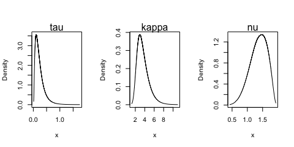

```r
par(mfrow=c(1,3))
plot(result_fit_ln, caption=c("tau","kappa","nu"))
```

### Changing the initial values

The inital values to be used by INLA’s optimization algorithm can be changed by setting the arguments `start.ltau`, `start.lkappa` and `start.nu`.

- `start.ltau` will be the initial value for $\log(\tau)$, that is, the logarithm of $\tau$.
- `start.lkappa` will be the inital value for $\log(\kappa)$, that is, the logarithm of $\kappa$.
- `start.nu` will be the initial value for $\nu$. Notice that here the initial value is *not* on the log scale.

One can change the initial value of one or more parameters.

For instance, let us consider the example with precipitation data, `rspde_order=3`, but change the initial values to the ones close to the fitted value when considering the default `rspde_order` (which is 2):

```r
rspde_model_order_3_start <- rspde.matern(mesh = prmesh, rspde_order = 3,
                              nu_upper_bound = 2,
                              start.lkappa = result_fit$summary.log.kappa$mean,
                              start.ltau = result_fit$summary.log.tau$mean,
                              start.nu = result_fit$summary.nu$mean)
```

Since we already computed the $A$ matrix and the index for `rspde_order=3`, all we have to do is to update the formula and fit:

```r
f.s.3.start <- y ~ -1 + Intercept +  f(seaDist, model = "rw1") +
  f(field, model = rspde_model_order_3_start)

rspde_fit_order_3_start <- inla(f.s.3.start, family = "Gamma",
                                data = inla.stack.data(stk.dat.3),
                    verbose = FALSE,
            control.inla=list(int.strategy='eb'),
            control.predictor = list(A = inla.stack.A(stk.dat.3),
                                     compute = TRUE),
            inla.mode = "experimental")
```

We have the summary:

```r
summary(rspde_fit_order_3_start)
```

```
##
## Call:
##    c("inla(formula = f.s.3.start, family = \"Gamma\", data =
##    inla.stack.data(stk.dat.3), ", " verbose = FALSE, control.predictor =
##    list(A = inla.stack.A(stk.dat.3), ", " compute = TRUE), control.inla =
##    list(int.strategy = \"eb\"), ", " inla.mode = \"experimental\")")
## Time used:
##     Pre = 5.63, Running = 66.5, Post = 0.101, Total = 72.2
## Fixed effects:
##            mean    sd 0.025quant 0.5quant 0.975quant  mode kld
## Intercept 0.486 0.013      0.461    0.486      0.511 0.486   0
##
## Random effects:
##   Name     Model
##     seaDist RW1 model
##    field RGeneric2
##
## Model hyperparameters:
##                                                    mean       sd 0.025quant
## Precision parameter for the Gamma observations   13.225    0.899     11.537
## Precision for seaDist                          8906.140 6499.752   2241.936
## Theta1 for field                                 -1.667    0.702     -3.106
## Theta2 for field                                  1.280    0.293      0.705
## Theta3 for field                                  0.705    0.678     -0.576
##                                                0.5quant 0.975quant     mode
## Precision parameter for the Gamma observations   13.197     15.074   13.147
## Precision for seaDist                          7131.571  26062.741 4813.438
## Theta1 for field                                 -1.644     -0.344   -1.560
## Theta2 for field                                  1.279      1.859    1.276
## Theta3 for field                                  0.681      2.088    0.597
##
## Marginal log-Likelihood:  -1261.62
## Posterior summaries for the linear predictor and the fitted values are computed
## (Posterior marginals needs also 'control.compute=list(return.marginals.predictor=TRUE)')
```

### Choosing between the optimized and non-optimized versions

The `rspde.matern()` function has an optimized version, which is the default and a non-optimized version.

It will take less time to fit the optimized object than to fit the non-optimized one. However it requires a sparsity analysis when creating the model object. If the size of the data is small it might happen that the time to analyze the sparsity plus the time to fit the model is larger than the time to fit non-optimized model, which does not require a sparsity analysis when creating the model object.

There is also another option for the optimized model, which is the `sharp` argument. The `sharp` argument is only used if `optimize` is `TRUE`. If `sharp=TRUE` the time to fit the model is less than the time to fit a model in which we have `sharp=FALSE`. However, the sparsity analysis takes more time when `sharp=TRUE` than when `sharp=FALSE`.

Let us then create the three model objects with `rspde_order=1` for the precipitation data and compare the times.

We begin by creating the $A$ matrix, index and `inla.stack` object that all the three models will use:

```r
Abar.1 <- rspde.make.A(mesh = prmesh, loc = coords, rspde_order=1)
mesh.index.1 <- rspde.make.index(name = "field", mesh = prmesh, rspde_order=1)
stk.dat.1 <- inla.stack(
  data = list(y = Y), A = list(Abar.1, 1), tag = "est",
  effects = list(c(mesh.index.1,
                   list(Intercept = 1)),
                 list(long = inla.group(coords[, 1]),
                      lat = inla.group(coords[,2]),
                      seaDist = inla.group(seaDist))))
```

Now, let us create the three models and compute the time it took to create the model objects:

```r
#Creating the optimized and sharp model
start_time <- Sys.time()
rspde_model_opt_sharp <- rspde.matern(mesh = prmesh,
                                      rspde_order = 1)
end_time <- Sys.time()
time_opt_sharp <- end_time - start_time

#Creating the optimized non-sharp model
start_time <- Sys.time()
rspde_model_opt_notsharp <- rspde.matern(mesh = prmesh,
                                         rspde_order = 1,
                                         sharp=FALSE)
end_time <- Sys.time()
time_opt_notsharp <- end_time - start_time

#Creating the non-optimized model
start_time <- Sys.time()
rspde_model_nonopt <- rspde.matern(mesh = prmesh,
                                   rspde_order = 1,
                                    optimize = FALSE)
end_time <- Sys.time()
time_nonopt <- end_time - start_time
```

Now, let us fit the models:

```r
f.s.opt.sharp <- y ~ -1 + Intercept +  f(seaDist, model = "rw1") +
  f(field, model = rspde_model_opt_sharp)

rspde_fit_opt_sharp <- inla(f.s.opt.sharp, family = "Gamma",
                            data = inla.stack.data(stk.dat.1),
                            verbose = FALSE,
                            control.inla=list(int.strategy='eb'),
                            control.predictor=list(A=inla.stack.A(stk.dat.1),
                                                     compute = FALSE),
            inla.mode = "experimental")

f.s.opt.notsharp <- y ~ -1 + Intercept +  f(seaDist, model = "rw1") +
  f(field, model = rspde_model_opt_notsharp)

rspde_fit_opt_notsharp <- inla(f.s.opt.notsharp, family = "Gamma",
                               data = inla.stack.data(stk.dat.1),
                               verbose = FALSE,
                               control.inla=list(int.strategy='eb'),
                               control.predictor=list(A=inla.stack.A(stk.dat.1),
                                                        compute = FALSE),
            inla.mode = "experimental")

f.s.nonopt <- y ~ -1 + Intercept +  f(seaDist, model = "rw1") +
  f(field, model = rspde_model_nonopt)

rspde_fit_nonopt <- inla(f.s.nonopt, family = "Gamma",
                         data = inla.stack.data(stk.dat.1),
                         verbose = FALSE,
                         control.inla=list(int.strategy='eb'),
                         control.predictor=list(A=inla.stack.A(stk.dat.1),
                                                  compute = FALSE),
            inla.mode = "experimental")
```

Finally, let us compare the times:

```r
`Time to create model` <- c(time_opt_sharp, time_opt_notsharp, time_nonopt)
`Time to fit the model` <- c(rspde_fit_opt_sharp$cpu.used[[2]],
                             rspde_fit_opt_notsharp$cpu.used[[2]],
                             rspde_fit_nonopt$cpu.used[[2]])
`Total time` <- `Time to create model` + `Time to fit the model`
Model <- c("Opt & sharp", "Opt & not sharp", "Non-opt")
result_table <- data.frame(Model, `Time to create model`,
                           `Time to fit the model`,
                           `Total time`)
result_table
```

```
##             Model Time.to.create.model Time.to.fit.the.model    Total.time
## 1     Opt & sharp        2.192289 secs              18.94193 21.13421 secs
## 2 Opt & not sharp        1.778021 secs              21.59339 23.37142 secs
## 3         Non-opt        1.388423 secs              32.51503 33.90346 secs
```

Therefore, we see that for this example one benefits from using the optimized version.

## An example with replicates

For this example we will simulate a data with replicates. We will use the same example considered in the Rational approximation with the `rSPDE` package vignette (the only difference is the way the data is organized). We also refer the reader to this vignette for a description of the function `matern.operators()`, along with its methods (for instance, the `simulate` method).

### Simulating the data

Let us consider a simple Gaussian linear model with 30 independent replicates of a latent spatial field $x(\mathbf{s})$, observed at the same $m$ locations, $\{\mathbf{s}_1 , \ldots , \mathbf{s}_m \}$, for each replicate. For each $i = 1,\ldots,m,$ we have

$$\begin{align}
y_i &= x_1(\mathbf{s}_i)+\varepsilon_i,\\
\vdots &= \vdots\\
y_{i+29m} &= x_{30}(\mathbf{s}_i) + \varepsilon_{i+29m},
\end{align}$$

where $\varepsilon_1,\ldots,\varepsilon_{30m}$ are iid normally distributed with mean 0 and standard deviation 0.1.

We use the basis function representation of $x(\cdot)$ to define the $A$ matrix linking the point locations to the mesh. We also need to account for the fact that we have 30 replicates at the same locations. To this end, the $A$ matrix we need can be generated by `inla.spde.make.A()` function. The reason being that we are sampling $x(\cdot)$ directly and not the latent vector described in the introduction of the Rational approximation with the `rSPDE` package vignette.

We begin by creating the mesh:

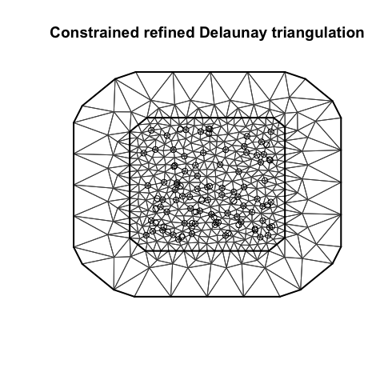

```r
m = 100
loc_2d_mesh = matrix(runif(m*2),m,2)
mesh_2d = inla.mesh.2d(
  loc=loc_2d_mesh,
  cutoff=0.05,
  offset=c(0.1,0.4),
  max.edge=c(0.05,0.5) )
plot(mesh_2d)
points(loc_2d_mesh[,1],loc_2d_mesh[,2])
```

We then compute the $A$ matrix, which is needed for simulation, and connects the observation locations to the mesh:

```r
n.rep = 30
A=inla.spde.make.A(
  mesh=mesh_2d,
  loc=loc_2d_mesh,
  index=rep(1:m,times=n.rep),
  repl=rep(1:n.rep,each=m))
```

Notice that for the simulated data, we should use the $A$ matrix from `inla.spde.make.A` function.

We will now simulate a latent process with standard deviation $\sigma=1$ and range $0.1$. We will use $\nu=0.5$ so that the model has an exponential covariance function. To this end we create a model object with the `CBrSPDE.matern.operators()` function:

```r
nu = 0.5
sigma = 1
range = 0.1
kappa = sqrt(8*nu)/range
tau = 1/(sqrt(4*pi)*kappa*sigma)
d=2
operator_information = matern.operators (mesh=mesh_2d,
                                 nu=nu,
                                 kappa=kappa,
                                 sigma=sigma,
                                 m=2)
```

More details on this function can be found at the Covariance-based rational approximation with the `rSPDE` package vignette.

To simulate the latent process all we need to do is to use the `simulate` method on the `operator_information` object. We then obtain the simulated data $y$ by connecting with the $A$ matrix and adding the gaussian noise.

```r
set.seed(1)
u = simulate(operator_information, nsim=n.rep)
y = as.vector(A %*% as.vector(u)) +
  rnorm(m*n.rep)*0.1
```

The first replicate of the simulated random field as well as the observation locations are shown in the following figure.

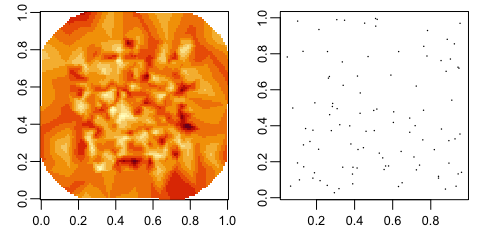

### Fitting the R-INLA rSPDE model

Let us then use the rational SPDE approach to fit the data.

We begin by creating the $A$ matrix and index with replicates, and the `inla.stack` object. It is important to notice that since we have replicates we should provide the `index` and `repl` arguments for `rspde.make.A()` function, and also the argument `n.repl` in `rspde.make.index()` function. They behave identically as in their `INLA`’s counterparts, namely, `inla.spde.make.A()` and `inla.make.index()`.

```r
Abar.rep <- rspde.make.A(mesh = mesh_2d, loc = loc_2d_mesh, index=rep(1:m,times=n.rep),
                     repl=rep(1:n.rep,each=m) )
mesh.index.rep <- rspde.make.index(name = "field", mesh = mesh_2d,
                                n.repl=n.rep)

st.dat.rep=inla.stack(
  data=list(y=y),
  A=Abar.rep,
  effects=mesh.index.rep)
```

We now create the model object.

```r
rspde_model.rep <- rspde.matern(mesh = mesh_2d)
```

Finally, we create the formula and fit. It is extremely important not to forget the `replicate` argument when building the formula as `inla()` function will not produce warning and might fit some meaningless model.

```r
f.rep =
  y ~ -1 + f(field, model=rspde_model.rep,
    replicate=field.repl)
rspde_fit.rep =
  inla(f.rep,
       data=inla.stack.data(st.dat.rep),
       family="gaussian",
       control.predictor=
         list(A=inla.stack.A(st.dat.rep)),
            inla.mode = "experimental")
```

We can get the summary:

```r
summary(rspde_fit.rep)
```

```
##
## Call:
##    c("inla(formula = f.rep, family = \"gaussian\", data =
##    inla.stack.data(st.dat.rep), ", " control.predictor = list(A =
##    inla.stack.A(st.dat.rep)), inla.mode = \"experimental\")" )
## Time used:
##     Pre = 5.33, Running = 375, Post = 2.52, Total = 383
## Random effects:
##   Name     Model
##     field RGeneric2
##
## Model hyperparameters:
##                                          mean    sd 0.025quant 0.5quant
## Precision for the Gaussian observations 93.28 5.281      83.98    92.83
## Theta1 for field                        -2.74 0.090      -2.92    -2.74
## Theta2 for field                         3.10 0.028       3.04     3.10
## Theta3 for field                        -1.50 0.035      -1.57    -1.50
##                                         0.975quant  mode
## Precision for the Gaussian observations     104.94 91.51
## Theta1 for field                             -2.54 -2.74
## Theta2 for field                              3.16  3.10
## Theta3 for field                             -1.42 -1.50
##
## Marginal log-Likelihood:  -1582.47
## Posterior summaries for the linear predictor and the fitted values are computed
## (Posterior marginals needs also 'control.compute=list(return.marginals.predictor=TRUE)')
```

and the summary in the user’s scale:

```r
result_fit_rep <- rspde.result(rspde_fit.rep, "field", rspde_model.rep)
summary(result_fit_rep)
```

```
##             mean        sd 0.025quant   0.5quant 0.975quant       mode
## tau    0.0646105 0.0058039  0.0540927  0.0644514  0.0770677  0.0638645
## kappa 22.2871000 0.6157790 21.1281000 22.3030000 23.5570000 22.2835000
## nu     0.7293740 0.0209210  0.6899570  0.7302660  0.7725470  0.7299570
```

```r
result_df <- data.frame(parameter = c("tau","kappa","nu"),
                      true = c(tau, kappa, nu),
                      mean = c(result_fit_rep$summary.tau$mean,
                              result_fit_rep$summary.kappa$mean,
                              result_fit_rep$summary.nu$mean),
                        mode = c(result_fit_rep$summary.tau$mode,
                                 result_fit_rep$summary.kappa$mode,
                                 result_fit_rep$summary.nu$mode))
print(result_df)
```

```
##   parameter        true        mean        mode
## 1       tau  0.01410474  0.06461052  0.06386446
## 2     kappa 20.00000000 22.28706181 22.28350471
## 3        nu  0.50000000  0.72937445  0.72995686
```

## References

Bolin, David, and Kristin Kirchner. 2020. “The Rational SPDE Approach for Gaussian Random Fields with General Smoothness.” *Journal of Computational and Graphical Statistics* 29 (2): 274–85.

Lindgren, Finn, Håvard Rue, and Johan Lindström. 2011. “An Explicit Link Between Gaussian Fields and Gaussian Markov Random Fields: The Stochastic Partial Differential Equation Approach.” *Journal of the Royal Statistical Society. Series B. Statistical Methodology* 73 (4): 423–98.